# Looking at covariates

Katia de Paiva Lopes Raj Lab Department of Neuroscience Icahn School of Medicine at Mount Sinai NYC, New York

2020-06-30

> 255 samples (from 314) | Different brain regions from the same donor | Multi disease cohort.

Previous R script: 01_expression_metadata_4reg.R by Katia Lopes.

```r
work_dir = "~/ad-omics/ricardo/tmp/3rd_pass_mic_258s/"
expression_dir = "~/ad-omics_hydra/microglia_omics/expression_tables/added_pilot_314s/expr_4brain_regions/"
metadata_path = "~/pd-omics/katia/Microglia/mic_255s/metadata_files/"
```

## Input: metadata

This metadata contains biological and technical covariates.

```r
load(paste0(metadata_path, "metadata_255filt_eng_29jun2020.Rdata"))
# str(metadata3rd_pass)

metadata <- metadata3rd_pass[, ! colnames(metadata3rd_pass) %in% c("C5", "C6", "C7", "C8", "C9", "C10")]
rownames(metadata) = metadata$donor_tissue
```

## HM: correlating the covariates

“Evaluating the correlation between variables in a important part in interpreting variancePartition results. When comparing two **continuous** variables, Pearson correlation is widely used. But variancePartition includes **categorical** variables in the model as well. In order to accommodate the correlation between a continuous and a categorical variable, or two categorical variables we used canonical correlation analysis. **Canonical Correlation Analysis (CCA)** is similar to correlation between two vectors, except that CCA can accommodate matricies as well.” Gabriel Hoffman.

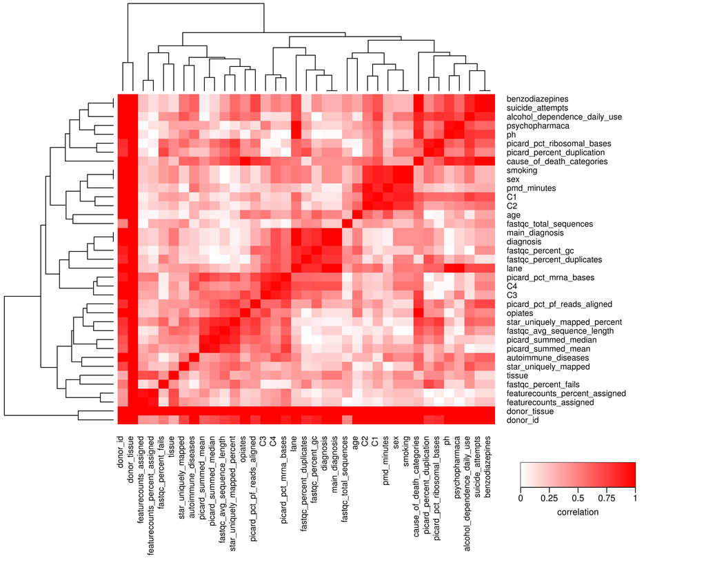

```r
# These variables have zero variance so cannot be analyzed:
#  infection_2weeks, glucocorticosteroids, batch

metadata_alt1 = metadata %>% dplyr::select(-glucocorticosteroids) # These variables have zero variance so cannot be analyzed: glucocorticosteroids
metadata_alt2 = metadata_alt1 %>% dplyr::select(-infection_2weeks) # These variables have zero variance so cannot be analyzed: infection_2weeks
metadata_alt = metadata_alt2 %>% dplyr::select(-batch) # These variables have zero variance so cannot be analyzed: batch

# names(metadata_alt) = tolower(names(metadata_alt))

# Transforms characters columns in factors columns
indx <- sapply(metadata_alt, is.character)
metadata_alt[indx] <- lapply(metadata_alt[indx], function(x) as.factor(x))
metadata_alt$ph = as.numeric(as.character(metadata_alt$ph))
#str(metadata_alt) #shows class for all columns
form <- as.formula(paste("", paste(colnames(metadata_alt), collapse=" + "), sep=" ~ ")) #form contains the design
C = canCorPairs(form, metadata_alt)

# pdf(paste0(work_dir, "figures_pdf/canonical_hm.pdf"), width = 10, height = 8)
plotCorrMatrix(C, margins = c(12,18))
# dev.off()
```

```r
### Number of tissues by donor
tissuesBydonor = rowSums(table(metadata_alt[,c("donor_id","tissue")]))
createDT(as.data.frame(tissuesBydonor))
```

### Donors with 01 tissue

```r
sum(rowSums(table(metadata_alt[,c("donor_id","tissue")]))==1)
```

[1] 26

```r
donor1sample = names(which(rowSums(table(metadata_alt[,c("donor_id","tissue")]))>1))
donor1sample
```

[1] “13-080” “14-005” “14-015” “14-029” “14-069” “14-075” “15-018” “15-024” [9] “15-055” “15-075” “15-087” “15-089” “15-093” “15-107” “16-003” “16-024” [17] “16-027” “16-028” “16-033” “16-046” “16-049” “16-056” “16-062” “16-065” [25] “16-067” “16-078” “16-080” “16-110” “16-111” “16-112” “16-116” “16-117” [33] “16-118” “16-137” “17-003” “17-005” “17-009” “17-012” “17-013” “17-015” [41] “17-016” “17-017” “17-029” “17-032” “17-043” “17-074” “17-078” “17-092” [49] “17-094” “17-097” “17-099” “17-102” “17-121” “17-124” “17-128” “17-136” [57] “17-148” “18-010” “18-012” “18-018” “18-021” “18-023” “18-039” “18-063” [65] “18-064” “18-074” “18-079” “18-105” “18-112” “MG-06” “MG-08” “MG-10” [73] “MG-11” “MG-13” ## Input expression

```r
load(paste0(expression_dir, "Expression_filt_255s.Rdata"))
# dim(genes_counts_exp_3rd) # 19376   255
```

## VP: 255 samples

The covariates for the formula was chosen based on canonical correlation. We need to be careful to interpret this plot because here, we are using all samples together: same individual with different brain regions.

If the covariate have NAs in the column, we can’t fit a model for Limma or Dream. The following covariates have NAs: **lane, benzodiapezines, opiates, autoimmune_diseases, smoking, infection_2weeks, alcohol_dependence_daily_use, ph, C1-C4 from genotyping, suicide_attempts and cause_of_death_categories**.

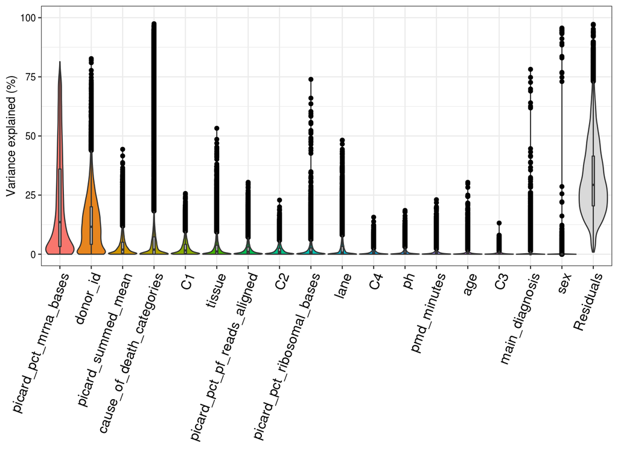

```r
library(doParallel)
cl <- makeCluster(10)
registerDoParallel(cl)

# For categorical covariates you need to include the number 1. Example: (1|Status) + (1|Plate)
metadata_alt$fastqc_total_sequences = scale(metadata_alt$fastqc_total_sequences)
metadata_alt$star_uniquely_mapped = scale(metadata_alt$star_uniquely_mapped)
metadata_alt$featurecounts_assigned = scale(metadata_alt$featurecounts_assigned)

# form <- ~ (1|donor_id) + age + (1|tissue) + (1|lane) + (1|main_diagnosis) + (1|sex) + pmd_minutes + picard_pct_mrna_bases + picard_summed_mean + picard_pct_pf_reads_aligned + ph + picard_pct_ribosomal_bases + (1|cause_of_death_categories) + C1 + C2 + C3 + C4 + (1|suicide_attempts) + fastqc_total_sequences + (1|opiates) + (1|autoimmune_diseases) + star_uniquely_mapped + fastqc_percent_fails + featurecounts_assigned

form <- ~ (1|donor_id) + age + (1|tissue) + (1|lane) + (1|main_diagnosis) + (1|sex) + pmd_minutes + picard_pct_mrna_bases + picard_summed_mean + picard_pct_pf_reads_aligned + ph + picard_pct_ribosomal_bases + (1|cause_of_death_categories) + C1 + C2 + C3 + C4

varPart_tx <- suppressWarnings( fitExtractVarPartModel( genes_counts_voom_3rd, form, metadata_alt) )
vp <- sortCols( varPart_tx )
# plotPercentBars( vp[1:10,] ) Not applicable for dataset with different tissues from the same individual

save(varPart_tx, file = paste0(work_dir, "/vp_files/varPart_tx_255s.RData"))
plotVarPart(vp) +
  ggeasy::easy_rotate_x_labels(angle = 70, side = c("right"))
```

## VP: By tissue (255 samples)

We have tried to run including +0 in the formula (Vignette, page 19) but it didn’t works because we have some donors with only one tissue. So, we can’t fit a model for that. However, we can try to run separately by tissue.

```r
metadata_GFM = metadata_alt[metadata_alt$tissue=="MFG",]
voom_GFM = genes_counts_voom_3rd[ , as.character(metadata_GFM$donor_tissue)]

metadata_GTS = metadata_alt[metadata_alt$tissue=="STG",]
voom_GTS = genes_counts_voom_3rd[ , as.character(metadata_GTS$donor_tissue)]

metadata_SVZ = metadata_alt[metadata_alt$tissue=="SVZ",]
voom_SVZ = genes_counts_voom_3rd[ , as.character(metadata_SVZ$donor_tissue)]

metadata_THA = metadata_alt[metadata_alt$tissue=="THA",]
voom_THA = genes_counts_voom_3rd[ , as.character(metadata_THA$donor_tissue)]

save(metadata_alt, metadata_GFM, metadata_GTS, metadata_SVZ, metadata_THA,
             voom_GFM, voom_GTS, voom_SVZ, voom_THA, file = paste0(work_dir, "metadata_exprBytissue_255s.Rdata"))
```

```r
form <- ~ age + (1|lane) + (1|main_diagnosis) + (1|sex) + pmd_minutes + picard_pct_mrna_bases + picard_summed_mean + picard_pct_pf_reads_aligned + ph + picard_pct_ribosomal_bases + (1|cause_of_death_categories) + C1 + C2 + C3 + C4
```

### MFG - Medial Frontal Gyrus

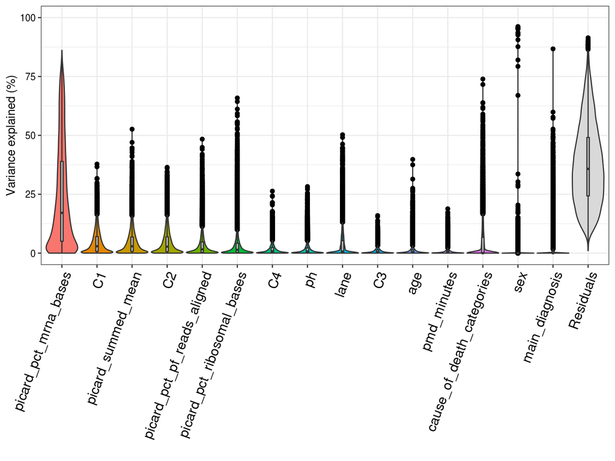

```r
varPart_tx <- suppressWarnings( fitExtractVarPartModel( voom_GFM, form, metadata_GFM) )
vp <- sortCols( varPart_tx )
save(varPart_tx, file = paste0(work_dir, "vp_files/varPart_tx_MFG.RData"))

plotVarPart(vp)+
  ggeasy::easy_rotate_x_labels(angle = 70, side = c("right"))
```

### STG - Superior Temporal Gyrus

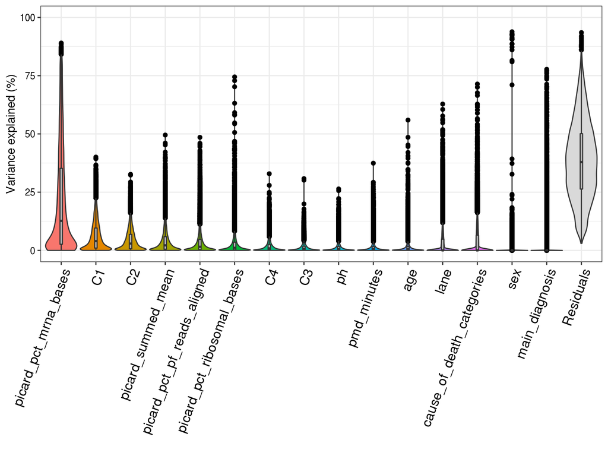

```r
varPart_tx <- suppressWarnings( fitExtractVarPartModel( voom_GTS, form, metadata_GTS) )
vp <- sortCols( varPart_tx )
save(varPart_tx, file = paste0(work_dir, "vp_files/varPart_tx_STG.RData"))

plotVarPart(vp)+
  ggeasy::easy_rotate_x_labels(angle = 70, side = c("right"))
```

### SVZ - Subventricular zone

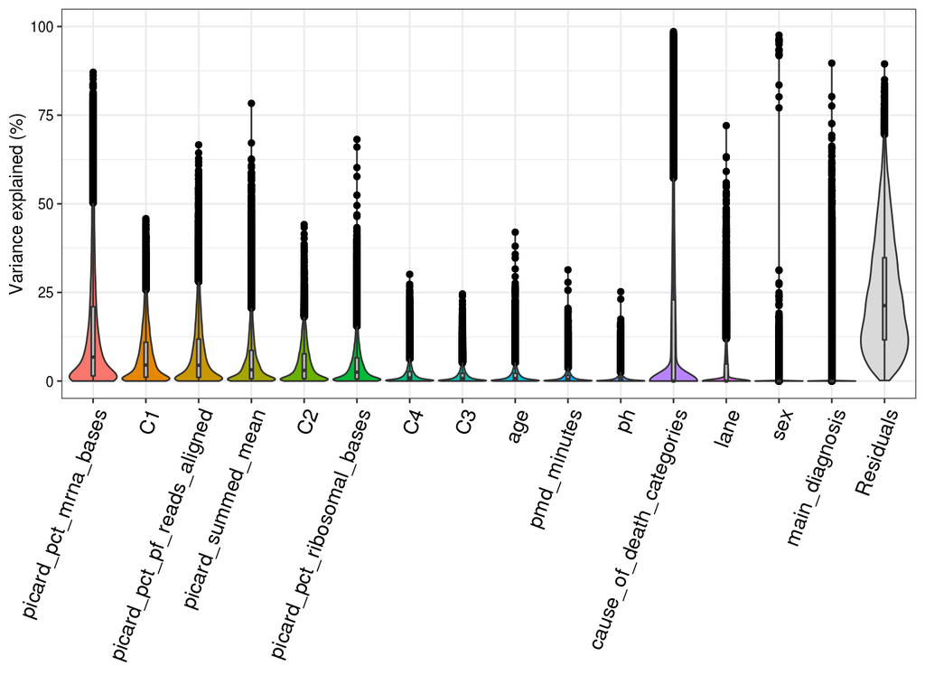

```r
varPart_tx <- suppressWarnings( fitExtractVarPartModel( voom_SVZ, form, metadata_SVZ) )
vp <- sortCols( varPart_tx )
save(varPart_tx, file = paste0(work_dir, "vp_files/varPart_tx_SVZ.RData"))

plotVarPart(vp) +
  ggeasy::easy_rotate_x_labels(angle = 70, side = c("right"))
```

### THA - Thalamus

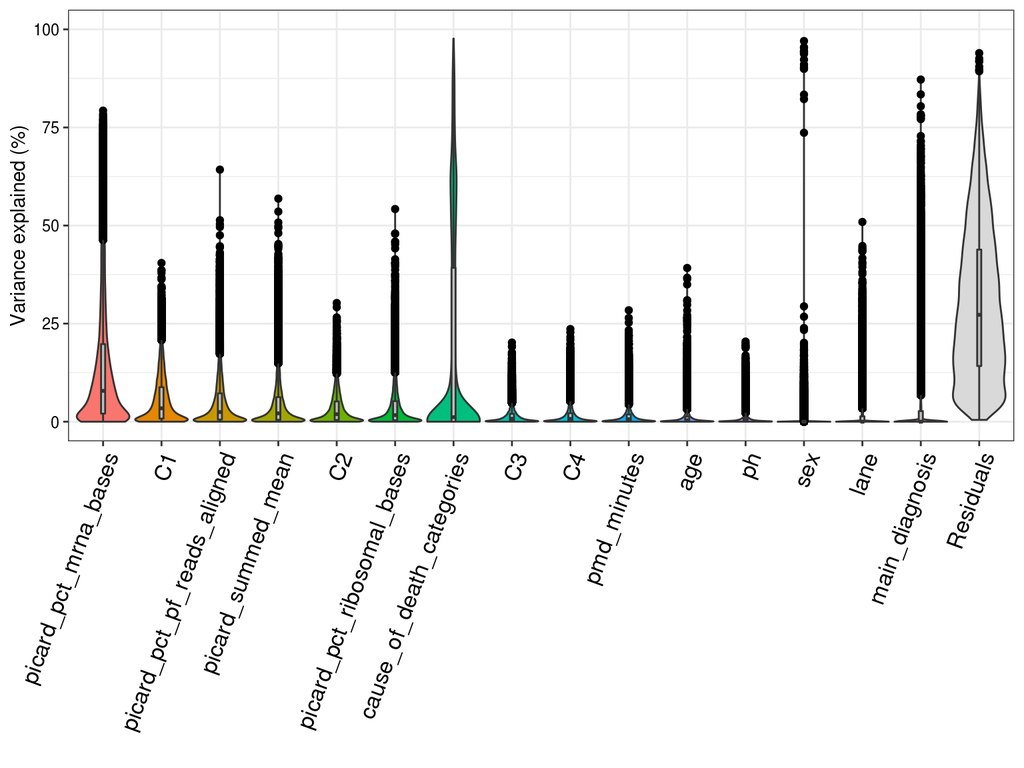

```r
varPart_tx <- suppressWarnings( fitExtractVarPartModel( voom_THA, form, metadata_THA) )
vp <- sortCols( varPart_tx )
save(varPart_tx, file = paste0(work_dir, "vp_files/varPart_tx_THA.RData"))

plotVarPart(vp)+
  ggeasy::easy_rotate_x_labels(angle = 70, side = c("right"))
```

## VP: 216 samples, European only

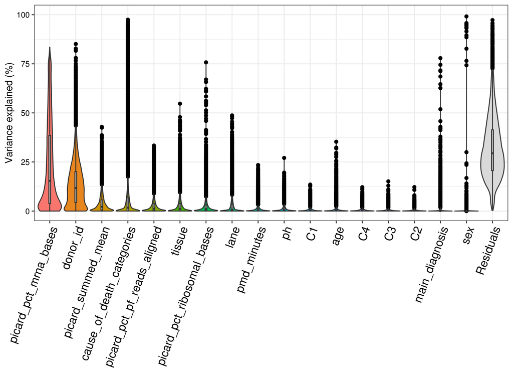

```r
eur_samples = read.table("~/pd-omics/katia/Microglia/mic_255s/samples_eqtl_90d.txt", header = F, stringsAsFactors = T)
colnames(eur_samples) = c("eur_samples")

metadata_alt_eur = metadata_alt[metadata_alt$donor_id %in% eur_samples$eur_samples ,]
genes_counts_voom_3rd_eur = genes_counts_voom_3rd[, colnames(genes_counts_voom_3rd) %in% metadata_alt_eur$donor_tissue]

form <- ~ (1|donor_id) + age + (1|tissue) + (1|lane) + (1|main_diagnosis) + (1|sex) + pmd_minutes + picard_pct_mrna_bases + picard_summed_mean + picard_pct_pf_reads_aligned + ph + picard_pct_ribosomal_bases + (1|cause_of_death_categories) + C1 + C2 + C3 + C4

varPart_tx <- suppressWarnings( fitExtractVarPartModel( genes_counts_voom_3rd_eur, form, metadata_alt_eur) )
vp <- sortCols( varPart_tx )
# plotPercentBars( vp[1:10,] ) Not applicable for dataset with different tissues from the same individual

save(varPart_tx, file = paste0(work_dir, "/vp_files/varPart_tx_eur_216s.RData"))
plotVarPart(vp) +
  ggeasy::easy_rotate_x_labels(angle = 70, side = c("right"))
```

R version 3.6.2 (2019-12-12) Platform: x86_64-pc-linux-gnu (64-bit) Running under: CentOS Linux 7 (Core)

Matrix products: default BLAS/LAPACK: /hpc/packages/minerva-centos7/intel/parallel_studio_xe_2019/compilers_and_libraries_2019.0.117/linux/mkl/lib/intel64_lin/libmkl_gf_lp64.so

locale: [1] LC_CTYPE=en_US.UTF-8 LC_NUMERIC=C  
[3] LC_TIME=en_US.UTF-8 LC_COLLATE=en_US.UTF-8  
[5] LC_MONETARY=en_US.UTF-8 LC_MESSAGES=en_US.UTF-8  
[7] LC_PAPER=en_US.UTF-8 LC_NAME=C  
[9] LC_ADDRESS=C LC_TELEPHONE=C  
[11] LC_MEASUREMENT=en_US.UTF-8 LC_IDENTIFICATION=C

attached base packages: [1] stats4 parallel stats graphics grDevices utils datasets [8] methods base

other attached packages: [1] doParallel_1.0.15 iterators_1.0.12  
[3] forcats_0.5.0 stringr_1.4.0  
[5] dplyr_0.8.5 purrr_0.3.3  
[7] readr_1.3.1 tidyr_1.1.0  
[9] tibble_3.0.1 tidyverse_1.3.0  
[11] broom_0.5.5 edgeR_3.28.1  
[13] DESeq2_1.26.0 SummarizedExperiment_1.16.1 [15] DelayedArray_0.12.2 BiocParallel_1.20.1  
[17] matrixStats_0.55.0 GenomicRanges_1.38.0  
[19] GenomeInfoDb_1.22.0 IRanges_2.20.2  
[21] S4Vectors_0.24.3 pamr_1.56.1  
[23] survival_3.1-11 cluster_2.1.0  
[25] factoextra_1.0.6 gplots_3.0.3  
[27] ggfortify_0.4.9 variancePartition_1.17.7  
[29] Biobase_2.46.0 BiocGenerics_0.32.0  
[31] scales_1.1.0 foreach_1.4.8  
[33] limma_3.42.2 ggplot2_3.3.0

loaded via a namespace (and not attached): [1] readxl_1.3.1 backports_1.1.5 Hmisc_4.3-1  
[4] plyr_1.8.6 splines_3.6.2 digest_0.6.25  
[7] htmltools_0.4.0 gdata_2.18.0 fansi_0.4.1  
[10] magrittr_1.5 checkmate_2.0.0 memoise_1.1.0  
[13] annotate_1.64.0 modelr_0.1.6 prettyunits_1.1.1  
[16] jpeg_0.1-8.1 colorspace_1.4-1 blob_1.2.1  
[19] rvest_0.3.5 ggrepel_0.8.2 haven_2.2.0  
[22] xfun_0.12 crayon_1.3.4 RCurl_1.98-1.1  
[25] jsonlite_1.6.1 genefilter_1.68.0 lme4_1.1-21  
[28] glue_1.3.1 gtable_0.3.0 zlibbioc_1.32.0  
[31] XVector_0.26.0 DBI_1.1.0 Rcpp_1.0.3  
[34] xtable_1.8-4 progress_1.2.2 htmlTable_1.13.3  
[37] foreign_0.8-76 bit_1.1-15.2 Formula_1.2-3  
[40] htmlwidgets_1.5.1 httr_1.4.1 RColorBrewer_1.1-2  
[43] acepack_1.4.1 ellipsis_0.3.0 farver_2.0.3  
[46] pkgconfig_2.0.3 XML_3.99-0.3 nnet_7.3-13  
[49] dbplyr_1.4.2 locfit_1.5-9.1 labeling_0.3  
[52] tidyselect_1.1.0 rlang_0.4.6 reshape2_1.4.3  
[55] AnnotationDbi_1.48.0 munsell_0.5.0 cellranger_1.1.0  
[58] tools_3.6.2 cli_2.0.2 generics_0.0.2  
[61] RSQLite_2.2.0 evaluate_0.14 yaml_2.2.1  
[64] knitr_1.28 bit64_0.9-7 fs_1.3.2  
[67] caTools_1.18.0 nlme_3.1-145 xml2_1.2.5  
[70] compiler_3.6.2 pbkrtest_0.4-8.6 rstudioapi_0.11  
[73] png_0.1-7 reprex_0.3.0 geneplotter_1.64.0  
[76] stringi_1.4.6 lattice_0.20-40 Matrix_1.2-18  
[79] nloptr_1.2.2.1 vctrs_0.3.1 pillar_1.4.3  
[82] lifecycle_0.2.0 data.table_1.12.8 bitops_1.0-6  
[85] colorRamps_2.3 R6_2.4.1 latticeExtra_0.6-29  
[88] KernSmooth_2.23-16 gridExtra_2.3 codetools_0.2-16  
[91] boot_1.3-24 MASS_7.3-51.5 gtools_3.8.1  
[94] assertthat_0.2.1 withr_2.1.2 GenomeInfoDbData_1.2.2 [97] hms_0.5.3 grid_3.6.2 rpart_4.1-15  
[100] minqa_1.2.4 rmarkdown_2.1 lubridate_1.7.9  
[103] base64enc_0.1-3 ggeasy_0.1.1